# Chatlize generated report

https://Chatlize.ai

2023-07-19

### System

**Act as an experienced data scientist and statistician. Write R code to analyze data following instructions.**

### Step 1

Prompt: Write R code. Do not include explanation. Load the data2.csv file into R. Show the first few rows. These columns are numeric: ASL, ASW, APL, and APW. The Sp column is either C or V.

```r
# Load the data2.csv file into R
data <- read.csv("data2.csv")

# Show the first few rows of the data
head(data)
```

```
##   ASL ASW APL APW Sp
## 1 7.0 3.2 4.7 1.4  C
## 2 6.4 3.2 4.5 1.5  C
## 3 6.9 3.1 4.9 1.5  C
## 4 5.5 2.3 4.0 1.3  C
## 5 6.5 2.8 4.6 1.5  C
## 6 5.7 2.8 4.5 1.3  C
```

```r
# Check the data structure and summary
str(data)
```

```
## 'data.frame':    100 obs. of  5 variables:
##  $ ASL: num  7 6.4 6.9 5.5 6.5 5.7 6.3 4.9 6.6 5.2 ...
##  $ ASW: num  3.2 3.2 3.1 2.3 2.8 2.8 3.3 2.4 2.9 2.7 ...
##  $ APL: num  4.7 4.5 4.9 4 4.6 4.5 4.7 3.3 4.6 3.9 ...
##  $ APW: num  1.4 1.5 1.5 1.3 1.5 1.3 1.6 1 1.3 1.4 ...
##  $ Sp : chr  "C" "C" "C" "C" ...
```

```r
summary(data)
```

```
##       ASL             ASW             APL             APW
##  Min.   :4.900   Min.   :2.000   Min.   :3.000   Min.   :1.000
##  1st Qu.:5.800   1st Qu.:2.700   1st Qu.:4.375   1st Qu.:1.300
##  Median :6.300   Median :2.900   Median :4.900   Median :1.600
##  Mean   :6.262   Mean   :2.872   Mean   :4.906   Mean   :1.676
##  3rd Qu.:6.700   3rd Qu.:3.025   3rd Qu.:5.525   3rd Qu.:2.000
##  Max.   :7.900   Max.   :3.800   Max.   :6.900   Max.   :2.500
##       Sp
##  Length:100
##  Class :character
##  Mode  :character
##
##
##
```

### Step 2

Prompt: Write R code. Do not include explanation. Check the structure of the imported data using the str() function.

```r
str(data)
```

```
## 'data.frame':    100 obs. of  5 variables:
##  $ ASL: num  7 6.4 6.9 5.5 6.5 5.7 6.3 4.9 6.6 5.2 ...
##  $ ASW: num  3.2 3.2 3.1 2.3 2.8 2.8 3.3 2.4 2.9 2.7 ...
##  $ APL: num  4.7 4.5 4.9 4 4.6 4.5 4.7 3.3 4.6 3.9 ...
##  $ APW: num  1.4 1.5 1.5 1.3 1.5 1.3 1.6 1 1.3 1.4 ...
##  $ Sp : chr  "C" "C" "C" "C" ...
```

### Step 3

Prompt: Write R code. Do not include explanation. Calculate summary statistics.

```r
summary(data)
```

```
##       ASL             ASW             APL             APW
##  Min.   :4.900   Min.   :2.000   Min.   :3.000   Min.   :1.000
##  1st Qu.:5.800   1st Qu.:2.700   1st Qu.:4.375   1st Qu.:1.300
##  Median :6.300   Median :2.900   Median :4.900   Median :1.600
##  Mean   :6.262   Mean   :2.872   Mean   :4.906   Mean   :1.676
##  3rd Qu.:6.700   3rd Qu.:3.025   3rd Qu.:5.525   3rd Qu.:2.000
##  Max.   :7.900   Max.   :3.800   Max.   :6.900   Max.   :2.500
##       Sp
##  Length:100
##  Class :character
##  Mode  :character
##
##
##
```

### Step 4

Prompt: Write R code. Do not include explanation. Explore the distribution of each numeric column individually by creating histograms.

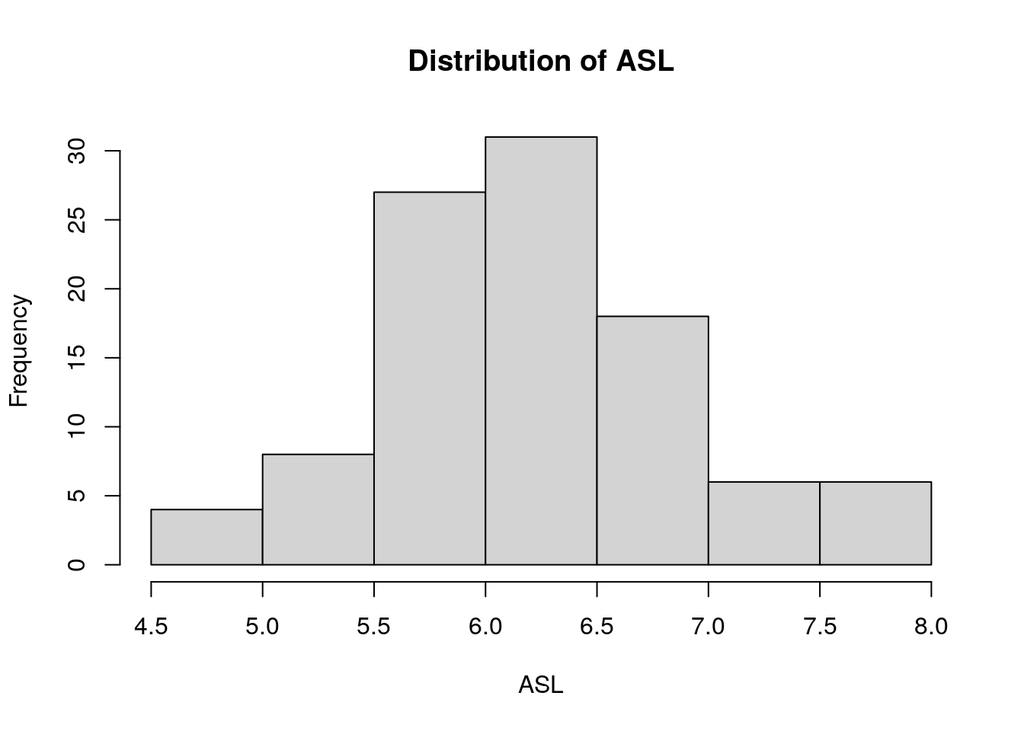

```r
# Create histograms for each numeric column
hist(data$ASL, main = "Distribution of ASL", xlab = "ASL")
```

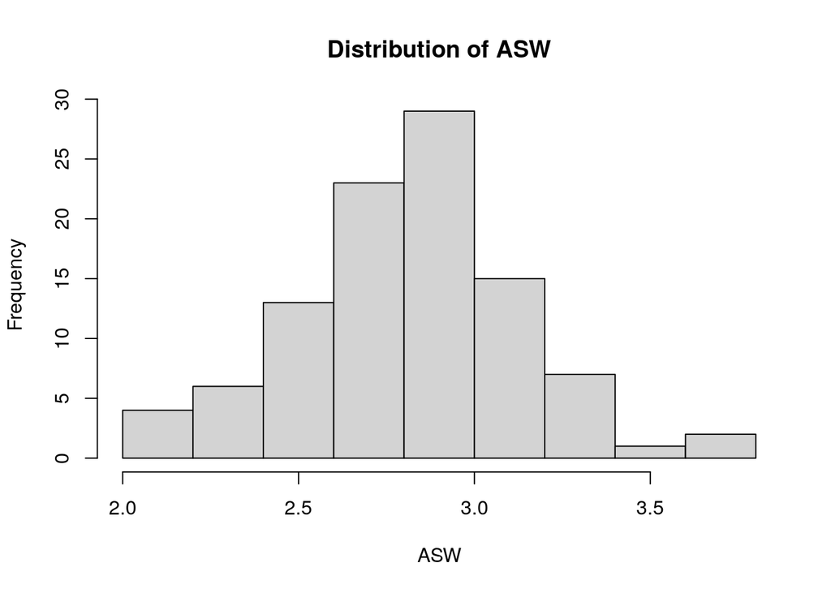

```r
hist(data$ASW, main = "Distribution of ASW", xlab = "ASW")
```

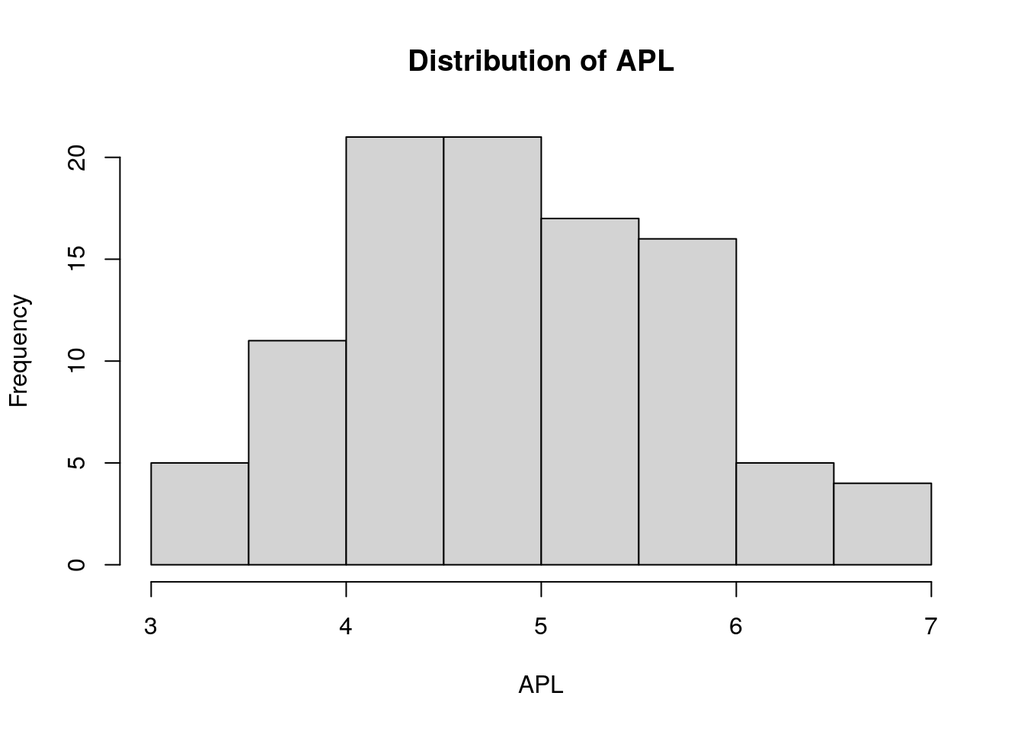

```r
hist(data$APL, main = "Distribution of APL", xlab = "APL")
```

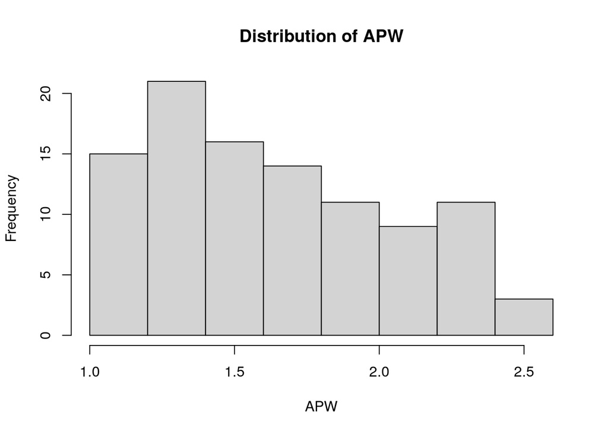

```r
hist(data$APW, main = "Distribution of APW", xlab = "APW")
```

### Step 5

Prompt: Write R code. Do not include explanation. Examine the relationships between the numeric variables by creating scatter plots using ggplot2. Include separate plots for each combination of the variables. Change color and shapge by Sp.

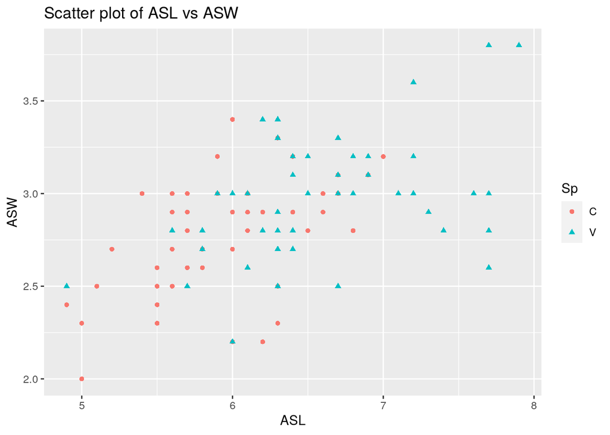

```r
pacman::p_load(ggplot2)

# Scatter plot for ASL vs ASW colored and shaped by Sp
ggplot(data, aes(x = ASL, y = ASW, color = Sp, shape = Sp)) +
  geom_point() +
  labs(x = "ASL", y = "ASW") +
  ggtitle("Scatter plot of ASL vs ASW")
```

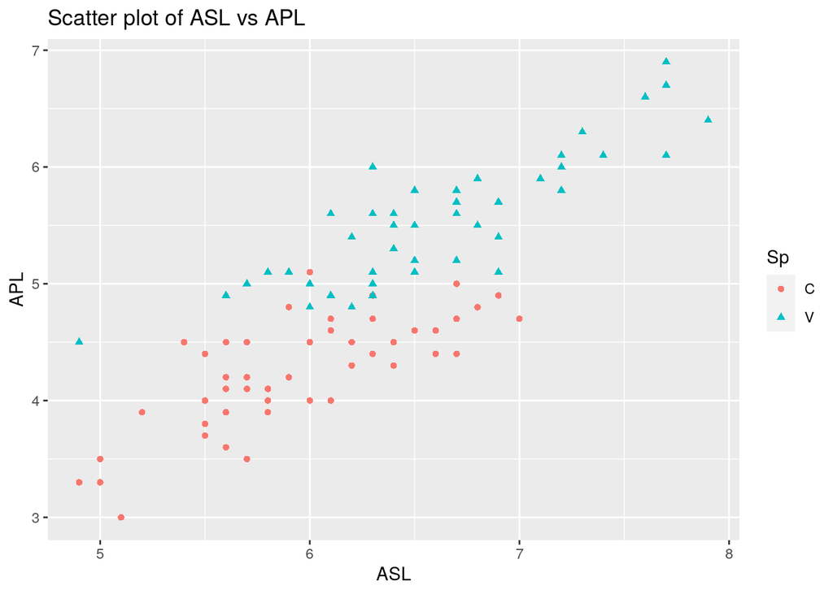

```r
# Scatter plot for ASL vs APL colored and shaped by Sp
ggplot(data, aes(x = ASL, y = APL, color = Sp, shape = Sp)) +
  geom_point() +
  labs(x = "ASL", y = "APL") +
  ggtitle("Scatter plot of ASL vs APL")
```

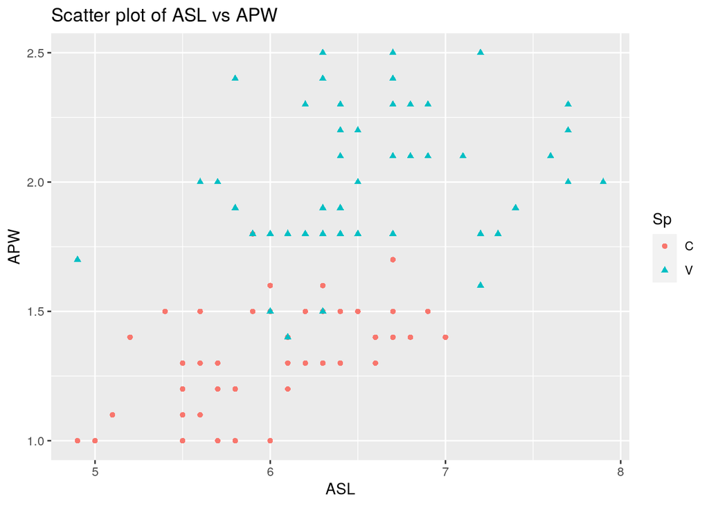

```r
# Scatter plot for ASL vs APW colored and shaped by Sp
ggplot(data, aes(x = ASL, y = APW, color = Sp, shape = Sp)) +
  geom_point() +
  labs(x = "ASL", y = "APW") +
  ggtitle("Scatter plot of ASL vs APW")
```

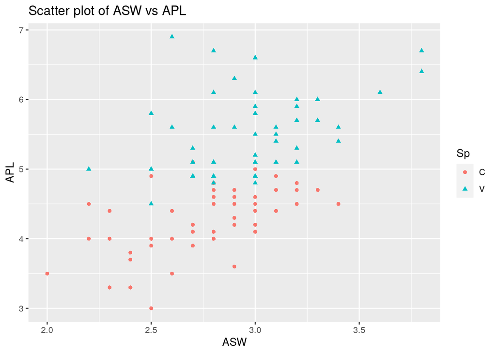

```r
# Scatter plot for ASW vs APL colored and shaped by Sp
ggplot(data, aes(x = ASW, y = APL, color = Sp, shape = Sp)) +
  geom_point() +
  labs(x = "ASW", y = "APL") +
  ggtitle("Scatter plot of ASW vs APL")
```

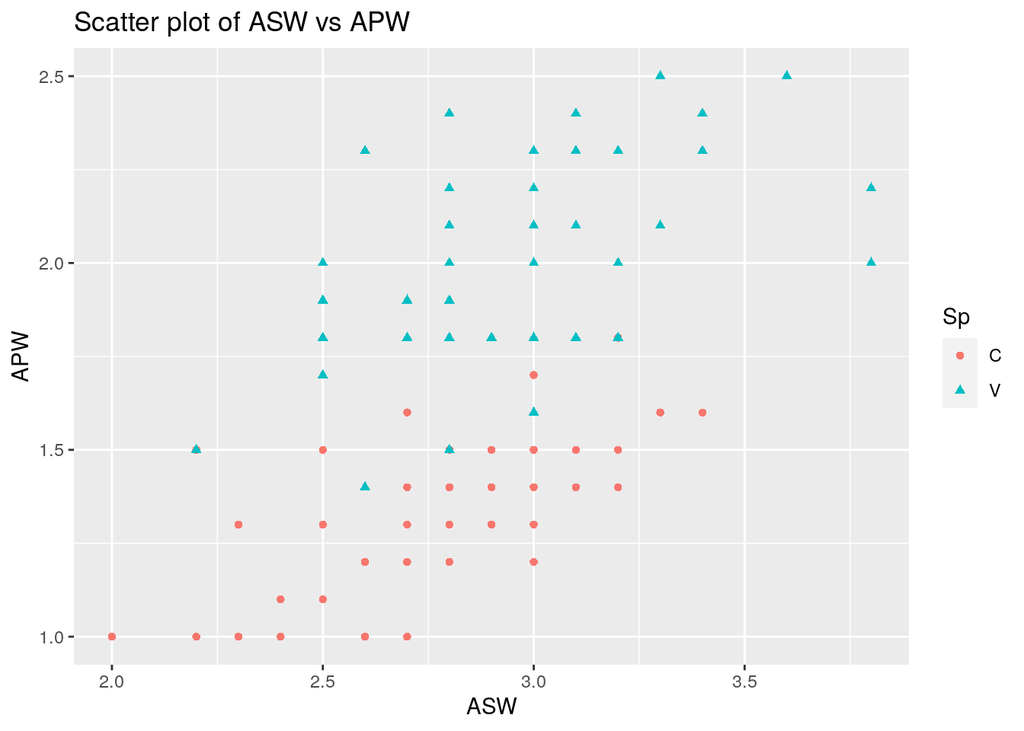

```r
# Scatter plot for ASW vs APW colored and shaped by Sp
ggplot(data, aes(x = ASW, y = APW, color = Sp, shape = Sp)) +
  geom_point() +
  labs(x = "ASW", y = "APW") +
  ggtitle("Scatter plot of ASW vs APW")
```

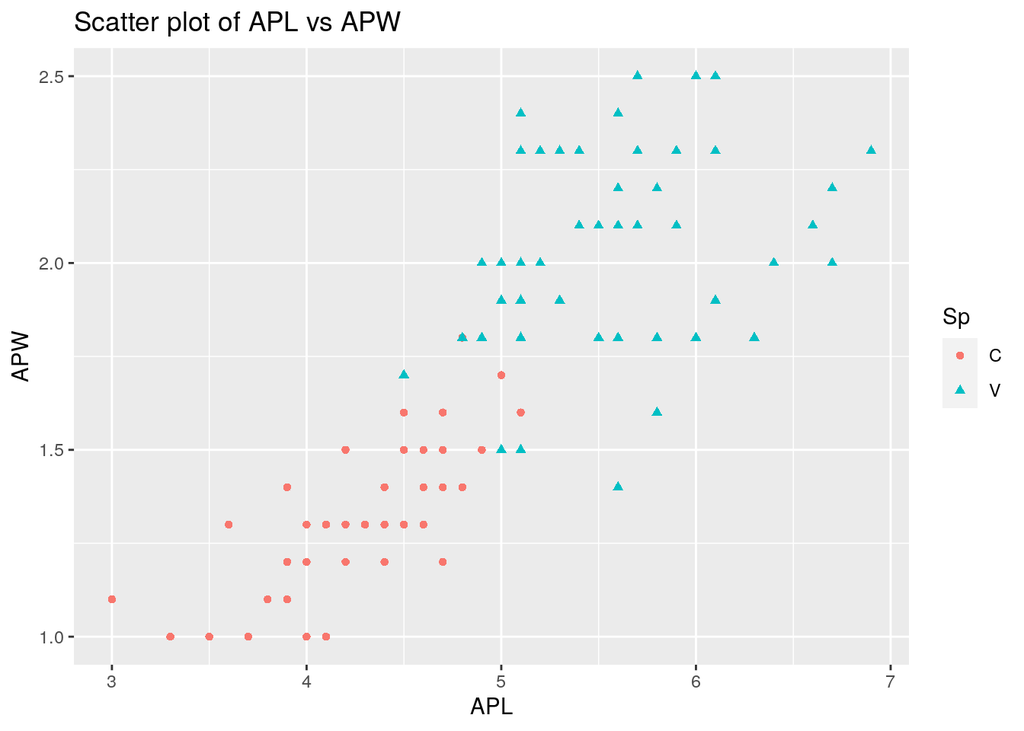

```r
# Scatter plot for APL vs APW colored and shaped by Sp
ggplot(data, aes(x = APL, y = APW, color = Sp, shape = Sp)) +
  geom_point() +
  labs(x = "APL", y = "APW") +
  ggtitle("Scatter plot of APL vs APW")
```

### Step 6

Prompt: Write R code. Do not include explanation. Visualize the differences between the groups for each numeric variable using box plots. Create separate box plots for each numeric variable, grouped by the Sp column. Add jitter points.

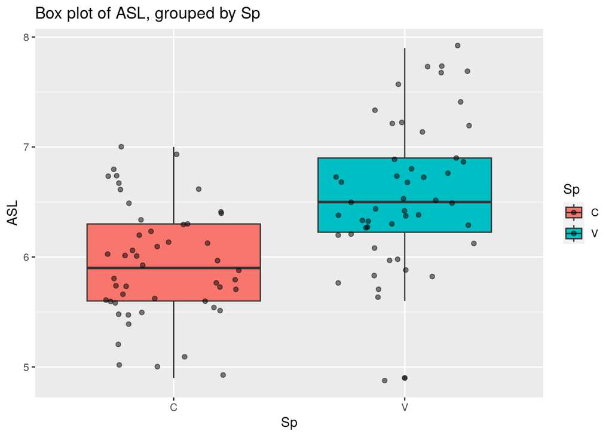

```r
# Box plot for ASL grouped by Sp
ggplot(data, aes(x = Sp, y = ASL, fill = Sp)) +
  geom_boxplot() +
  geom_jitter(width = 0.3, alpha = 0.5) +
  labs(x = "Sp", y = "ASL") +
  ggtitle("Box plot of ASL, grouped by Sp")
```

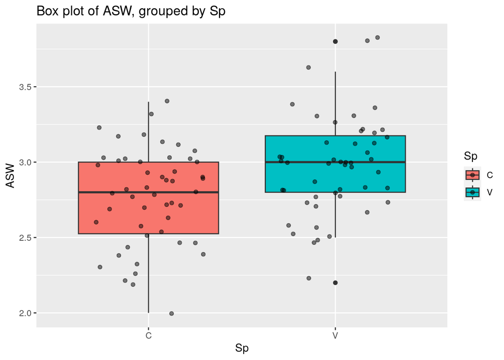

```r
# Box plot for ASW grouped by Sp
ggplot(data, aes(x = Sp, y = ASW, fill = Sp)) +
  geom_boxplot() +
  geom_jitter(width = 0.3, alpha = 0.5) +
  labs(x = "Sp", y = "ASW") +
  ggtitle("Box plot of ASW, grouped by Sp")
```

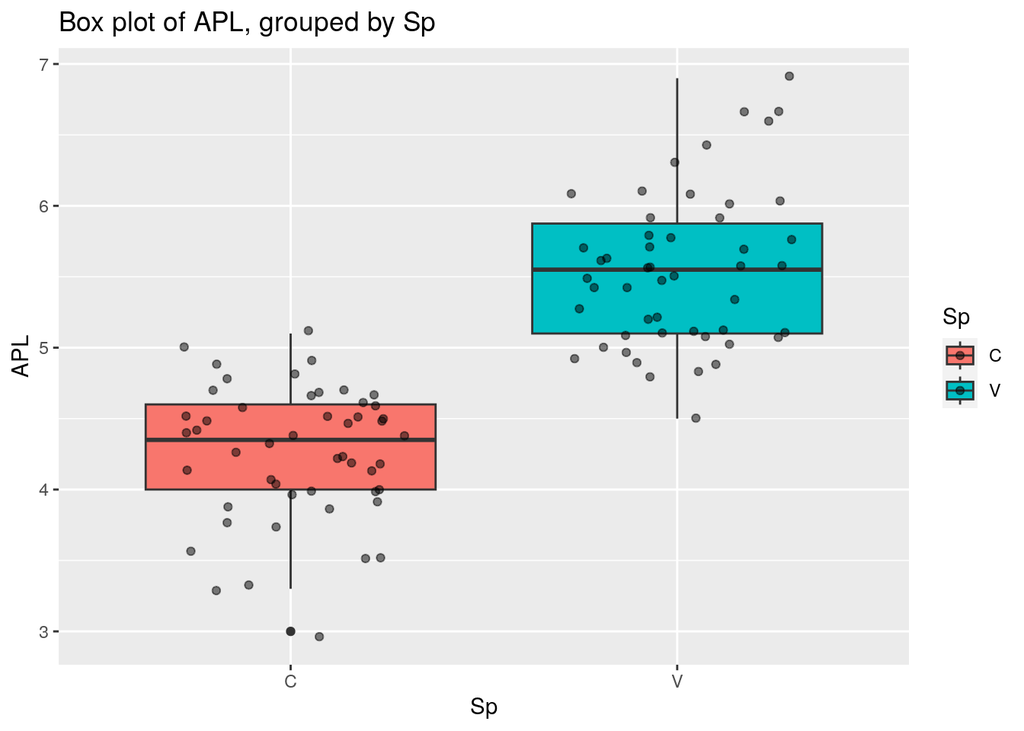

```r
# Box plot for APL grouped by Sp
ggplot(data, aes(x = Sp, y = APL, fill = Sp)) +
  geom_boxplot() +
  geom_jitter(width = 0.3, alpha = 0.5) +
  labs(x = "Sp", y = "APL") +
  ggtitle("Box plot of APL, grouped by Sp")
```

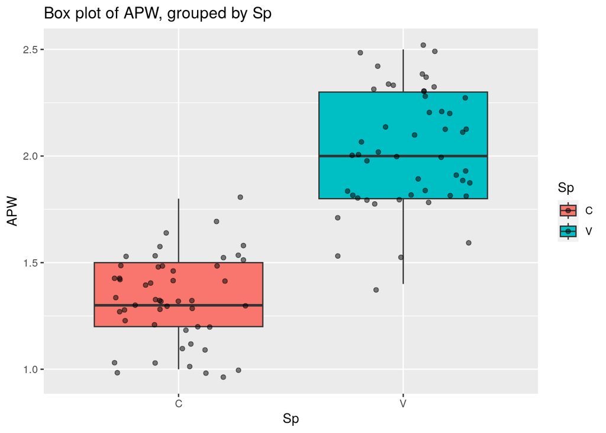

```r
# Box plot for APW grouped by Sp
ggplot(data, aes(x = Sp, y = APW, fill = Sp)) +
  geom_boxplot() +
  geom_jitter(width = 0.3, alpha = 0.5) +
  labs(x = "Sp", y = "APW") +
  ggtitle("Box plot of APW, grouped by Sp")
```

### Step 7

Prompt: Write R code. Do not include explanation. Perform a t-test for each numeric variable between the two groups (C and V).

```r
# t-test for ASL between C and V groups
t.test(ASL ~ Sp, data = data)
```

```
##
##  Welch Two Sample t-test
##
## data:  ASL by Sp
## t = -5.6292, df = 94.025, p-value = 1.866e-07
## alternative hypothesis: true difference in means between group C and group V is not equal to 0
## 95 percent confidence interval:
##  -0.8819731 -0.4220269
## sample estimates:
## mean in group C mean in group V
##           5.936           6.588
```

```r
# t-test for ASW between C and V groups
t.test(ASW ~ Sp, data = data)
```

```
##
##  Welch Two Sample t-test
##
## data:  ASW by Sp
## t = -3.2058, df = 97.927, p-value = 0.001819
## alternative hypothesis: true difference in means between group C and group V is not equal to 0
## 95 percent confidence interval:
##  -0.33028364 -0.07771636
## sample estimates:
## mean in group C mean in group V
##           2.770           2.974
```

```r
# t-test for APL between C and V groups
t.test(APL ~ Sp, data = data)
```

```
##
##  Welch Two Sample t-test
##
## data:  APL by Sp
## t = -12.604, df = 95.57, p-value < 2.2e-16
## alternative hypothesis: true difference in means between group C and group V is not equal to 0
## 95 percent confidence interval:
##  -1.49549 -1.08851
## sample estimates:
## mean in group C mean in group V
##           4.260           5.552
```

```r
# t-test for APW between C and V groups
t.test(APW ~ Sp, data = data)
```

```
##
##  Welch Two Sample t-test
##
## data:  APW by Sp
## t = -14.625, df = 89.043, p-value < 2.2e-16
## alternative hypothesis: true difference in means between group C and group V is not equal to 0
## 95 percent confidence interval:
##  -0.7951002 -0.6048998
## sample estimates:
## mean in group C mean in group V
##           1.326           2.026
```

### Step 8

Prompt: Write R code. Do not include explanation. Calculate the pairwise correlations between the numeric variables and construct a correlation matrix. Visualize the correlation matrix using a heatmap.

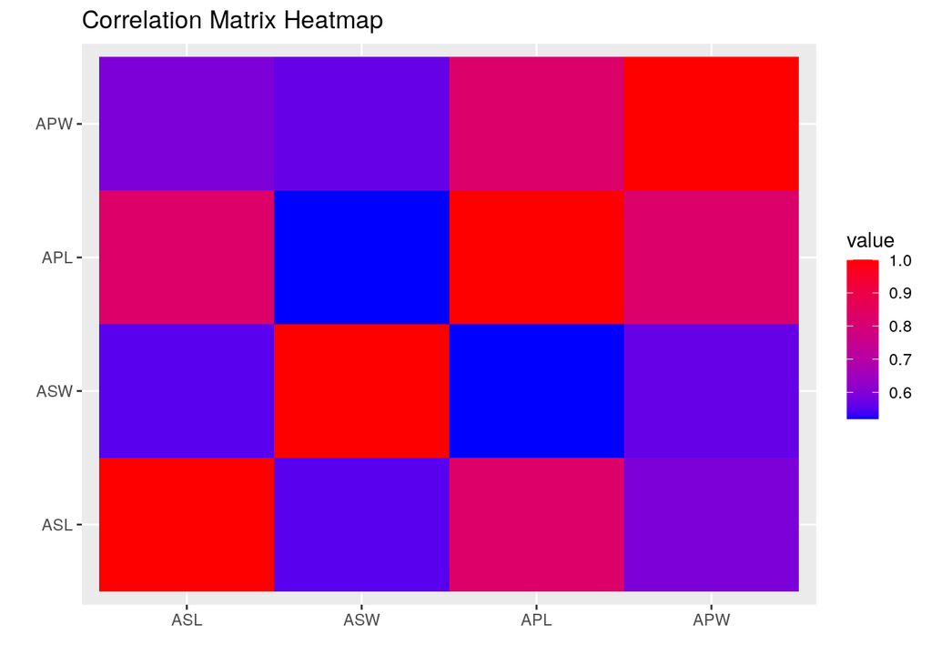

```r
# Calculate pairwise correlations between numeric variables
correlations <- cor(data[, c("ASL", "ASW", "APL", "APW")])

# Create correlation matrix heatmap
pacman::p_load(ggplot2)
pacman::p_load(reshape2)

melted_cor <- melt(correlations)
ggplot(data = melted_cor, aes(x = Var1, y = Var2, fill = value)) +
  geom_tile() +
  scale_fill_gradient(low = "blue", high = "red") +
  labs(x = "", y = "") +
  ggtitle("Correlation Matrix Heatmap")
```

Generated with https://Chatlize.ai. No guarantees! Still a work in progress. Contact Steven Ge (gexijin@gmail.com).